# E07 - RNA-seq / 04 - differential expression (Analysis of Gene Expression @ UCT Prague)

Copy, please, these files and directories to your personal directory:

```bash
cp -r ~/shared/AGE_current/Exercises/E07-RNA_seq/04_differential_expression ~/AGE/Exercises/E07-RNA_seq
```

# Introduction

In the previous tutorial we learned how to do normalization and transformation of counts and how to use these counts for exploratory analysis. We used PCA and hierarchical clustering to explore if experiment was done right. Our finding was that everything is OK and we can safely proceed to differential expression analysis.

# Data preparation

We will reuse the saved environment from the previous exercise. If you already haven’t run the code of the previous exercise, run its last “HTML rendering” chunk.

```r
library(conflicted)
library(here)
library(DESeq2)
conflict_prefer("rowRanges", "MatrixGenerics")
library(BiocParallel)
library(magrittr)
library(glue)

load(here("E07-RNA_seq/03_exploratory_analysis/03_exploratory_analysis.RData"))
source(here("age_library.R"))
register(BPPARAM)
```

# Differential expression

Because we have already run the `DESeq()` function, we now have a fitted linear model used for testing of differential expression. The design was:

```r
design(dds)
```

```
## ~cell + dex
## <environment: 0x55a82b7f95f8>
```

We can show the names of contrasts. Contrasts are used to compare gene expression between sample groups.

```r
resultsNames(dds)
```

```
## [1] "Intercept"               "cell_N061011_vs_N052611" "cell_N080611_vs_N052611" "cell_N61311_vs_N052611"  "dex_trt_vs_untrt"
```

You can see that `DESeq2` generated contrasts between reference levels (the first ones) vs. all other levels from all explanatory variables specified in the design. You can check the reference levels, that is, the first levels:

```r
dds$cell
```

```
## [1] N61311  N61311  N052611 N052611 N080611 N080611 N061011 N061011
## Levels: N052611 N061011 N080611 N61311
```

```r
dds$dex
```

```
## [1] untrt trt   untrt trt   untrt trt   untrt trt
## Levels: untrt trt
```

Later you will see how to obtain results for any contrast, not just for some_level vs. reference_level.

> For a perfect explanation of formulas, design matrices, contrasts, additive effects, interaction terms etc., see Chapter 5 - Linear Models in [PH525x series - Biomedical Data Science](http://genomicsclass.github.io/book/). The whole materials are awesome, and by the way one of the authors is Mike Love, the developer of `DESeq2`. You can find it also in [HarvardX Biomedical Data Science Open Online Training](http://rafalab.github.io/pages/harvardx.html), where are also links to theoretical lectures.

## Two group comparisons

We assume that effects of `cell` and `dex` are additive, i.e. they do not interact. That means the effect of changes in a predictor on a response is independent of the effect(s) of changes in other predictor(s).

So, for example, the contrast `cell_N061011_vs_N052611` mean: is there a significant change in expression of cell line `N061011` in comparison with cell line `N052611`, regardless the treatment, which has the same effect for all cell lines?

Similarly, the contrast `dex_trt_vs_untrt` mean: is there a significant change in expression of `trt` samples in comparison with `untrt` samples, regardless the cell line, which has the same effect for both treatments?

`results()` function is used to extract results for a specific contrast. You can use the contrast name from `resultsNames(dds)` or specify a custom contrast.

```r
res_dex <- results(dds, name = "dex_trt_vs_untrt", parallel = TRUE)
head(res_dex)
```

```
## log2 fold change (MLE): dex trt vs untrt
## Wald test p-value: dex trt vs untrt
## DataFrame with 6 rows and 6 columns
##                  baseMean log2FoldChange     lfcSE      stat      pvalue        padj
##                 <numeric>      <numeric> <numeric> <numeric>   <numeric>   <numeric>
## ENSG00000000003  708.5839     -0.3812438 0.1006569 -3.787556 1.52136e-04 1.25654e-03
## ENSG00000000419  520.2833      0.2068250 0.1119673  1.847190 6.47195e-02 1.91389e-01
## ENSG00000000457  237.1568      0.0379405 0.1425055  0.266239 7.90056e-01 9.07267e-01
## ENSG00000000460   57.9312     -0.0887308 0.2839549 -0.312482 7.54674e-01 8.89731e-01
## ENSG00000000971 5817.1912      0.4264088 0.0889024  4.796371 1.61566e-06 2.07705e-05
## ENSG00000001036 1282.0737     -0.2410581 0.0890373 -2.707383 6.78160e-03 3.30256e-02
```

What do all these columns mean?

- **baseMean**: mean of normalized counts across all samples.
- **log2FoldChange**: estimated LFC.
- **lfcSE**: standard error of the LFC.
- **stat**: Wald statistic: $\frac{\text{log2FoldChange}}{\text{lfcSE}}$
- **pvalue**: p-value.
- **padj**: p-value adjusted for multiple testing issue. The default adjusting method is FDR.

We can look at `res_dex` summary of differentially expressed genes (DEGs), defined by `padj < 0.1`:

```r
summary(res_dex, alpha = 0.1)
```

```
##
## out of 22008 with nonzero total read count
## adjusted p-value < 0.1
## LFC > 0 (up)       : 2624, 12%
## LFC < 0 (down)     : 2233, 10%
## outliers [1]       : 0, 0%
## low counts [2]     : 4267, 19%
## (mean count < 5)
## [1] see 'cooksCutoff' argument of ?results
## [2] see 'independentFiltering' argument of ?results
```

What does `alpha` actually mean? Because we are using FDR for p-value adjusting, it sets the acceptable proportion of false positives among all DEGs. So, for example, if we consider a fraction of 10 % false positives acceptable, we can consider all genes with an adjusted p-value (FDR) below 0.1 as DEGs.

## Using custom contrasts

Note that result names are created from comparisons of levels of each variable to its reference level, e.g. `N061011` vs. `N052611`. `constrast` parameter is used to specify a custom contrast. It is a character vector of length three: `c("condition", "level_to_compare", "base_level")`

We can, for example, compare cell lines `N061011` and `N080611`:

```r
res_cell <- results(dds, contrast = c("cell", "N061011", "N080611"))
head(res_cell)
```

```
## log2 fold change (MLE): cell N061011 vs N080611
## Wald test p-value: cell N061011 vs N080611
## DataFrame with 6 rows and 6 columns
##                  baseMean log2FoldChange     lfcSE      stat    pvalue      padj
##                 <numeric>      <numeric> <numeric> <numeric> <numeric> <numeric>
## ENSG00000000003  708.5839     -0.2555856  0.140164 -1.823470 0.0682323  0.295342
## ENSG00000000419  520.2833     -0.1119156  0.157512 -0.710523 0.4773797  0.794211
## ENSG00000000457  237.1568      0.1562295  0.199753  0.782115 0.4341471  0.763257
## ENSG00000000460   57.9312      0.3982702  0.391706  1.016759 0.3092681  0.660499
## ENSG00000000971 5817.1912      0.0429139  0.125295  0.342503 0.7319725  0.916441
## ENSG00000001036 1282.0737      0.2402859  0.125569  1.913579 0.0556740  0.258776
```

## Interactions

What if you want to know whether there is a difference between specific cell lines having a specific treatment? One possibility is to use interaction terms in design formula, but easier is to make a combined variable from `cell` and `dex`:

```r
dds$cell_dex <- glue("{dds$cell}_{dds$dex}") %>% factor()
colData(dds) %>% head()
```

```
## DataFrame with 6 rows and 11 columns
##            SampleName     cell      dex    albut        Run avgLength Experiment    Sample    BioSample sizeFactor      cell_dex
##              <factor> <factor> <factor> <factor>   <factor> <integer>   <factor>  <factor>     <factor>  <numeric>      <factor>
## SRR1039508 GSM1275862  N61311     untrt    untrt SRR1039508       126  SRX384345 SRS508568 SAMN02422669   1.023677 N61311_untrt
## SRR1039509 GSM1275863  N61311     trt      untrt SRR1039509       126  SRX384346 SRS508567 SAMN02422675   0.896237 N61311_trt
## SRR1039512 GSM1275866  N052611    untrt    untrt SRR1039512       126  SRX384349 SRS508571 SAMN02422678   1.179599 N052611_untrt
## SRR1039513 GSM1275867  N052611    trt      untrt SRR1039513        87  SRX384350 SRS508572 SAMN02422670   0.669959 N052611_trt
## SRR1039516 GSM1275870  N080611    untrt    untrt SRR1039516       120  SRX384353 SRS508575 SAMN02422682   1.177673 N080611_untrt
## SRR1039517 GSM1275871  N080611    trt      untrt SRR1039517       126  SRX384354 SRS508576 SAMN02422673   1.399118 N080611_trt
```

Now you can use the design `~ cell_dex` and compare, for example, `N61311_trt` vs. `N61311_untrt`. However, in our dataset there are no replicates of these groups, so we can’t use `DESeq2` to test them for differential expression.

We can change the design of DESeqDataSet, but it won’t automatically recompute all the statistics:

```r
dds_interaction <- dds
design(dds_interaction) <- ~ cell_dex
```

We have to run the `DESeq()` function again, but it will fail due to missing replicates:

```r
dds_interaction <- DESeq(dds_interaction, parallel = TRUE)
```

```
## Error in checkForExperimentalReplicates(object, modelMatrix):
##
##   The design matrix has the same number of samples and coefficients to fit,
##   so estimation of dispersion is not possible. Treating samples
##   as replicates was deprecated in v1.20 and no longer supported since v1.22.
```

You can see that `DESeq2` doesn’t allow us to use this design, because it doesn’t contain replicates, which are neccessary for DESeq’s statistical model. So always use biological replicates in your experiments 🙂

> The combination of factors to define interactions is even recommended in `DESeq2`s [vignette](https://bioconductor.org/packages/release/bioc/vignettes/DESeq2/inst/doc/DESeq2.html#interactions), because generally it is more interpretable. To see how interactions could be complicated, see example 3 in [?results()](https://rdrr.io/bioc/DESeq2/man/results.html).

> For an in-depth explanation of interaction terms, see [this chapter](http://genomicsclass.github.io/book/pages/interactions_and_contrasts.html) from the PH525x course mentioned above.

## Independent filtering

For weakly expressed genes, we have no chance of seeing differential expression, because the low read counts suffer from so high Poisson noise that any biological effect is drowned in the uncertainties from the read counting. At first sight, there may seem to be little benefit in filtering out these genes. After all, the test found them to be non-significant anyway. However, these genes have an influence on the multiple testing adjustment, whose performance improves if such genes are removed.

Independent filtering can be [fine-tuned](http://bioconductor.org/packages/devel/bioc/vignettes/DESeq2/inst/doc/DESeq2.html#independent-filtering-of-results) in `results()` function parameters.

As a consequence, some independently filtered genes have `NA` in `padj` column:

```r
res_dex[is.na(res_dex$padj), ] %>% head()
```

```
## log2 fold change (MLE): dex trt vs untrt
## Wald test p-value: dex trt vs untrt
## DataFrame with 6 rows and 6 columns
##                  baseMean log2FoldChange     lfcSE       stat    pvalue      padj
##                 <numeric>      <numeric> <numeric>  <numeric> <numeric> <numeric>
## ENSG00000002079   1.42771      -1.976828  1.815793 -1.0886858  0.276292        NA
## ENSG00000004468   1.31740      -1.032940  1.609701 -0.6416966  0.521070        NA
## ENSG00000005381   4.50299       0.187478  1.040789  0.1801310  0.857050        NA
## ENSG00000005513   4.43369      -1.289547  0.976046 -1.3211946  0.186436        NA
## ENSG00000006606   4.02515      -0.182908  0.925333 -0.1976674  0.843305        NA
## ENSG00000006747   1.90719      -0.113265  1.282901 -0.0882881  0.929648        NA
```

# Reporting DEA results

So now we have the table of differential expression results (`res_dex`). That’s good, but:

- We need to filter differentially expressed genes (DEGs):
  - Genes whose LFC is significant ($padj <= threshold$).
  - Genes having $|LFC| >= threshold$.
- We can generate more accurate LFC estimates using a procedure called shrinkage.
- In the results table there are only ENSEMBL IDs - extended annotation is more practical.
- Having this table only in R is not very comfortable, so we will export it to tabular format and HTML.
- Graphical report is very informative. We can use MA and volcano plot.

First we set our DEG filtering criteria:

```r
PADJ_THRESHOLD <- 0.1
LFC_THRESHOLD <- 1
```

> However, these thresholds are very subjective and depends on experiment you are analysing data from, and also on the data itself. Also, in some cases you may want to report statistics not only for DEGs, but for all genes.

## LFC shrinkage

*Taken from [here](https://github.com/hbctraining/DGE_workshop/blob/master/lessons/05_DGE_DESeq2_analysis2.md):*

To generate more accurate LFC estimates, `DESeq2` allows for the shrinkage of the LFC estimates toward zero when the information for a gene is low, which could include:

- Low counts.
- High dispersion values (in `DESeq2`s terms, dispersion is a measure of variability).

LFC shrinkage uses information from all genes to generate more accurate estimates. Specifically, the distribution of LFC estimates for all genes is used (as a prior) to shrink the LFC estimates of genes with little information or high dispersion toward more likely (lower) LFC estimates.

> Note that shrinking the LFCs will **not change** the total number of genes that are identified as significantly differentially expressed. The shrinkage of fold change is to help with downstream assessment of results. For example, if you wanted to subset your significant genes based on fold change for further evaluation, you may want to use shrunken values. Additionally, for functional analysis tools such as Gene Set Enrichment Analysis which require fold change values as input you would want to provide shrunken values.

```r
res_dex_shrink <- lfcShrink(dds, res = res_dex, type = "ashr", parallel = TRUE)
```

## Annotation of results

First we will annotate the results table by adding columns from `rowData()`:

```r
# Check if the results table contains the same genes as rowData.
stopifnot(all(rownames(res_dex_shrink) == rownames(rowData(dds))))

res_dex_shrink_ann <- cbind(res_dex_shrink, rowData(dds)[, c("SYMBOL", "GENENAME")])
# Order the results table by padj.
res_dex_shrink_ann <- res_dex_shrink_ann[order(res_dex_shrink_ann$padj), ]
head(res_dex_shrink_ann)
```

```
## DataFrame with 6 rows and 7 columns
##                  baseMean log2FoldChange     lfcSE       pvalue         padj      SYMBOL               GENENAME
##                 <numeric>      <numeric> <numeric>    <numeric>    <numeric> <character>            <character>
## ENSG00000152583   997.410        4.52655  0.184403 3.87953e-136 6.88268e-132     SPARCL1           SPARC like 1
## ENSG00000165995   495.089        3.26748  0.132753 2.56857e-135 2.27845e-131      CACNB2 calcium voltage-gate..
## ENSG00000120129  3408.961        2.92881  0.121788 4.37074e-129 2.58471e-125       DUSP1 dual specificity pho..
## ENSG00000101347 12703.198        3.73295  0.155947 1.36567e-128 6.05707e-125      SAMHD1 SAM and HD domain co..
## ENSG00000189221  2341.724        3.32642  0.142040 6.89933e-123 2.44802e-119        MAOA    monoamine oxidase A
## ENSG00000211445 12285.646        3.69181  0.166287 3.94527e-111 1.16655e-107        GPX3 glutathione peroxida..
```

## MA plot

The MA plot shows the mean of the normalized counts versus the LFCs for all genes tested. The genes that are significantly DE are colored to be easily identified. This is also a great way to illustrate the effect of the LFC shrinkage.

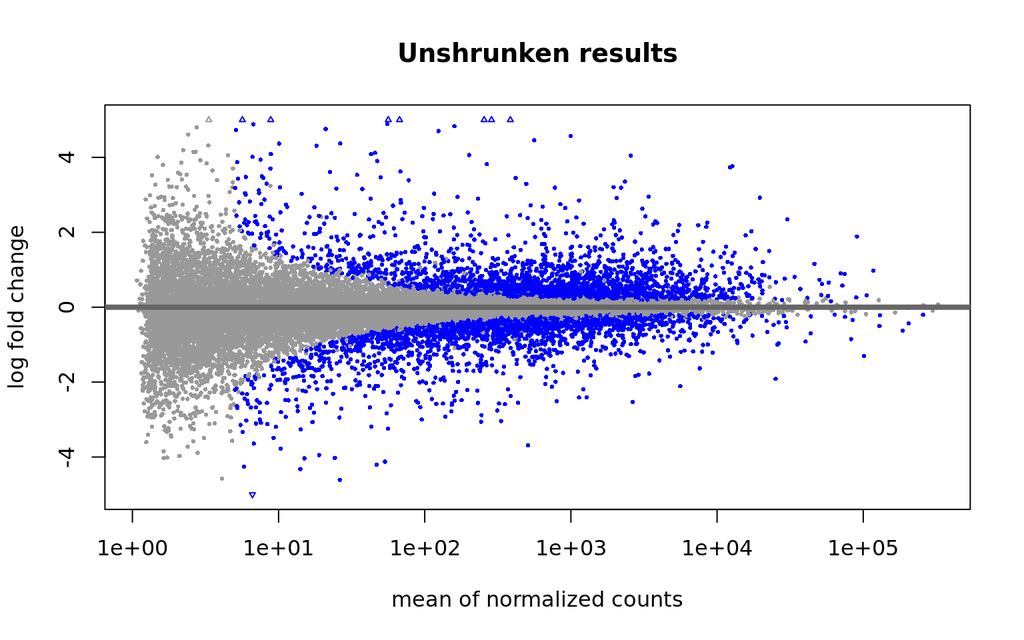

```r
plotMA(res_dex, alpha = PADJ_THRESHOLD, main = "Unshrunken results", ylim = c(-5, 5))
```

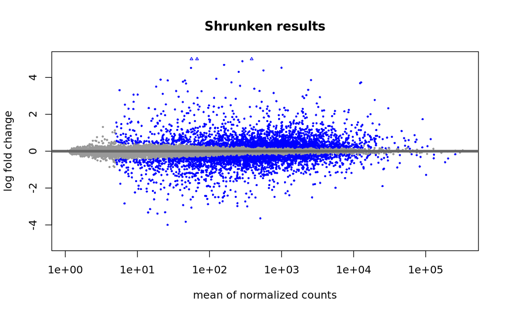

```r
plotMA(res_dex_shrink, alpha = PADJ_THRESHOLD, main = "Shrunken results", ylim = c(-5, 5))
```

In addition to the comparison described above, this plot allows us to evaluate the magnitude of fold changes and how they are distributed relative to mean expression. Generally, we would expect to see significant genes across the full range of expression levels.

Alternatively, we can use the [ggmaplot()](https://rpkgs.datanovia.com/ggpubr/reference/ggmaplot.html) function from `ggpubr` package. We can keep our `res_dex_shrink_ann` as is, because `ggmaplot()` is by default expecting output from `DESeq2`.

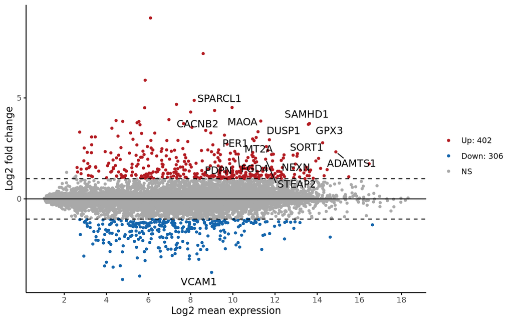

```r
ggpubr::ggmaplot(
  res_dex_shrink_ann,
  fdr = PADJ_THRESHOLD,
  fc = 2 ** LFC_THRESHOLD,
  genenames = res_dex_shrink_ann$SYMBOL,
  size = 1
)
```

## Volcano plot

Volcano plots are commonly used to display the results of RNA-seq or other omics experiments. A volcano plot is a type of scatterplot that shows statistical significance (p-value) versus magnitude of change (LFC). It enables quick visual identification of genes with large LFCs that are also statistically significant. In a volcano plot, the most upregulated genes are towards the right, the most downregulated genes are towards the left, and the most statistically significant genes are towards the top.

We will use [EnhancedVolcano](https://bioconductor.org/packages/release/bioc/html/EnhancedVolcano.html) package which produces [highly customizable](https://bioconductor.org/packages/release/bioc/vignettes/EnhancedVolcano/inst/doc/EnhancedVolcano.html) volcano plots in publication-ready quality.

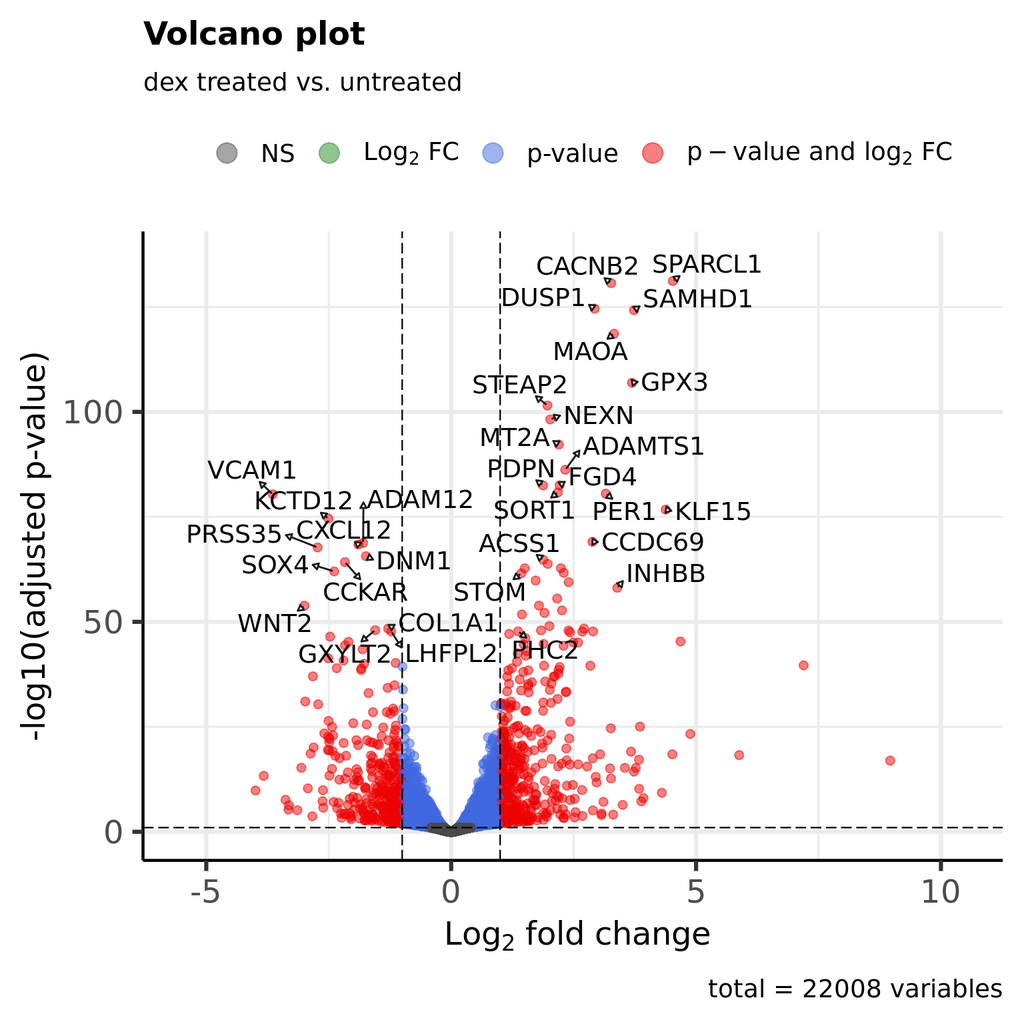

```r
EnhancedVolcano::EnhancedVolcano(
  # A dataframe.
  toptable = res_dex_shrink_ann,
  # Vector of gene names.
  lab = res_dex_shrink_ann$SYMBOL,
  # Which column from toptable parameter to use for x and y values.
  x = "log2FoldChange",
  y = "padj",
  # We want to label only first 50 genes from toptable. We already sort toptable by padj,
  # so we label first 50 most significant genes.
  selectLab = res_dex_shrink_ann[1:50, "SYMBOL"],
  # pvalue or padj cuttof (applied on y parameter).
  pCutoff = PADJ_THRESHOLD,
  # LFC cutoff (applied on x parameter).
  FCcutoff = LFC_THRESHOLD,
  title = "Volcano plot",
  subtitle = "dex treated vs. untreated",
  ylab = "-log10(adjusted p-value)",
  # To avoid overlapping gene labels, draw arrows for them.
  drawConnectors = TRUE
)
```

## Export of results to tabular formats

We can export filtered DEGs to e.g. a comma-separated file (CSV), or whatever tabular format is supported in R and its packages. These DEGs are matching our filtering criteria |LFC| >= 1 and FDR <= 0.1. We also filter out genes not passing the independent filtering (their `padj` is `NA`).

```r
deg_filter <- (!is.na(res_dex_shrink_ann$padj)) & (res_dex_shrink_ann$padj <= PADJ_THRESHOLD) & (abs(res_dex_shrink_ann$log2FoldChange) >= LFC_THRESHOLD)
table(deg_filter)
```

```
## deg_filter
## FALSE  TRUE
## 21300   708
```

```r
out_file <- "dex_trt_vs_untrt_degs.csv"
res_dex_shrink_filtered <- res_dex_shrink_ann[deg_filter, ]
write.csv(res_dex_shrink_filtered, file = here("E07-RNA_seq/04_differential_expression", out_file))
```

dex_trt_vs_untrt_degs.csv

> A much faster alternative to base R’s importing/exporting functions is [readr](https://readr.tidyverse.org/) package. Specifically for CSV import and export, there are functions [read_csv()](https://readr.tidyverse.org/reference/read_delim.html) and [write_csv()](https://readr.tidyverse.org/reference/write_delim.html), respectively.

To import and export Excel files, you can use [readxl](https://readxl.tidyverse.org/) and [writexl](https://docs.ropensci.org/writexl/) packages, respectively.

If you will use RMarkdown to report your analysis, you can output pretty HTML tables using [DT](https://rstudio.github.io/DT/) package:

```r
DT::datatable(
  as.data.frame(res_dex_shrink_filtered),
  filter = "top"
)
```

|  | baseMean | log2FoldChange | lfcSE | pvalue | padj | SYMBOL | GENENAME |
| --- | --- | --- | --- | --- | --- | --- | --- |
| ENSG00000152583 | 997.410354309803 | 4.52655434520876 | 0.184402616164094 | 3.87953314099946e-136 | 6.88267974544715e-132 | SPARCL1 | SPARC like 1 |
| ENSG00000165995 | 495.088726091201 | 3.26747504750371 | 0.132752525616915 | 2.56856552585633e-135 | 2.27844604971086e-131 | CACNB2 | calcium voltage-gated channel auxiliary subunit beta 2 |
| ENSG00000120129 | 3408.96081621086 | 2.92880718628514 | 0.121787557041481 | 4.37073901757596e-129 | 2.58470936369384e-125 | DUSP1 | dual specificity phosphatase 1 |
| ENSG00000101347 | 12703.1983347364 | 3.73294774134374 | 0.155947232078725 | 1.36566660107969e-128 | 6.05707279243871e-125 | SAMHD1 | SAM and HD domain containing deoxynucleoside triphosphate triphosphohydrolase 1 |
| ENSG00000189221 | 2341.72418995625 | 3.32641835890777 | 0.142040018695766 | 6.89933378327539e-123 | 2.44802161298177e-119 | MAOA | monoamine oxidase A |
| ENSG00000211445 | 12285.6462530561 | 3.69181165168964 | 0.166287101991412 | 3.94526507598724e-111 | 1.16654912855149e-107 | GPX3 | glutathione peroxidase 3 |
| ENSG00000157214 | 3009.21914845443 | 1.96521456719613 | 0.0909595490855734 | 1.18009301582924e-105 | 2.99086145626093e-102 | STEAP2 | STEAP2 metalloreductase |
| ENSG00000162614 | 5392.99661043581 | 2.02351482278721 | 0.0951923151705708 | 2.85637941524246e-102 | 6.33437840072705e-99 | NEXN | nexilin F-actin binding protein |
| ENSG00000125148 | 3656.16117849273 | 2.19691600288644 | 0.106448025252269 | 3.04636077584329e-96 | 6.00505405824842e-93 | MT2A | metallothionein 2A |
| ENSG00000154734 | 30314.4640976904 | 2.3291141440983 | 0.116593393525034 | 3.57381202980775e-90 | 6.34029992208193e-87 | ADAMTS1 | ADAM metallopeptidase with thrombospondin type 1 motif 1 |

[output cut: 698 more lines]

Finally, the code you created in the microarrays’ assignment (R script and Rmd files for reporting of DEGs) can be also easily used for RNA-seq data 🙂

# Cleanup

```r
save(list = ls(all.names = TRUE), file = here("E07-RNA_seq/04_differential_expression/04_differential_expression.RData"), envir = environment())

warnings()
traceback()
```

```
## No traceback available
```

# HTML rendering

This chunk is not evaluated (`eval = FALSE`). Otherwise you will probably end up in recursive hell 🤯

```r
library(conflicted)
library(knitr)
library(here)

if (!require(rmdformats)) {
  BiocManager::install("rmdformats")
}

# You can set global chunk options. Options set in individual chunks will override this.
opts_chunk$set(warning = FALSE, message = FALSE, eval = TRUE)
rmarkdown::render(
  here("E07-RNA_seq/04_differential_expression/04_differential_expression.Rmd"),
  output_file = here("E07-RNA_seq/04_differential_expression/04_differential_expression.html"),
  envir = new.env(),
  knit_root_dir = here()
)
```